# Gendered Disparities in Care Work: Comparing Childcare and Adult Care in India

Dr Preet Deep Singh[^1]

November 11, 2025

Abstract

Using a 10% random sample of India’s 2024 Time Use Survey (approximately 1 million person-day observations from 139,489 households), we provide population-level estimates of gender disparities across two forms of unpaid care work: childcare and adult care. We cannot condition on household composition (presence of children or elderly members). Men’s participation rates remain extremely low for both activities. The gender participation gap in childcare (16.2 percentage points) substantially exceeds that in adult care (4.1 percentage points). This pattern persists across education levels, urban-rural locations, and age groups, reflecting deeply entrenched cultural norms assigning care work to women. As India’s 60+ population share doubles to 20% by 2050, these findings highlight urgent needs for care infrastructure and cultural transformation.

**JEL Classification:** J12, J13, J14, J16, I10

**Keywords:** childcare, adult care, gender inequality, unpaid care work, aging, India, time use survey, household production, demographic transition

**Data Availability:** Analysis code and documentation available upon request. Original data from National Statistical Office Time Use Survey 2024.

# 1 Introduction

Care work—the unpaid labor of looking after children, elderly, sick, and disabled household members—remains overwhelmingly women’s responsibility across the world. Yet not all care work is the same. Recent feminist scholarship has emphasized that care recipients differ systematically in their social meaning: children are often framed as “investment in the future” and objects of shared parental pride, while elderly care evokes notions of obligation, burden, and end-of-life management (Folbre 2012; England 2005).

One might hypothesize that cultural differences in how societies view care recipients translate into different patterns of gendered participation. If childcare is partially legitimized as “parenting”—a responsibility that modern men increasingly acknowledge—then male participation may be non-trivial. By contrast, adult care, often stigmatized as difficult and unrewarding, may be seen as quintessentially women’s work, resulting in even lower male contributions.

Using a 10% random sample of India’s 2024 Time Use Survey (approximately 1 million person-day observations from 139,489 households), we examine gender disparities in these two types of care work. **Important limitation:** We cannot observe household composition (number/ages of children, presence of elderly members), so our estimates represent population-level gender gaps, not gaps conditional on care needs being present. We find that men’s participation in childcare is actually lower (relative to women) than their participation in adult care. The gender gap in childcare participation is approximately 4 times larger than the adult care gap, and this pattern persists across all education levels, geographic locations, and age groups. This suggests that in the Indian context, patriarchal norms assign *all* forms of care work primarily to women, with childcare being particularly feminized despite “involved fatherhood” rhetoric.

Our findings have profound policy implications. While both childcare and adult care remain highly feminized, the larger gender gaps in childcare suggest that current policy debates rightly focus on childcare support (day care centers, parental leave). However, as India’s population ages rapidly—with the 60+ share doubling from 10% in 2020 to 20% by 2050 (United Nations 2022)—adult care support will also become increasingly critical. Men’s low participation in both forms of care work threatens women’s health, employment, and wellbeing.

This paper proceeds as follows. Section 2 reviews relevant literature on gender and care work specialization. Section 3 describes the Time Use Survey data. Section 4 presents descriptive patterns. Section 5 reports regression results with controls and robustness checks. Section 6 discusses mechanisms and policy implications.

# 2 Literature Review

## 2.1 Gender Specialization in Care Work

Economic theories of household specialization (Becker 1981) predict that spouses divide labor to maximize joint utility, often resulting in women specializing in home production. Yet this framework treats all home production as homogeneous, ignoring variation across tasks. Recent work shows that even within unpaid work, certain tasks—cooking, laundry, cleaning—are disproportionately female, while others—home repairs, financial management—are male-dominated (Sayer 2005).

Care work represents the most time-intensive component of women’s unpaid labor. Studies from the US (Sayer, Bianchi, and Robinson 2004), Europe (Craig and Mullan 2011), and Asia (Choe and Retherford 2009) document that mothers perform 2-4 times as much childcare as fathers. However, most studies aggregate all care work, masking potential differences between childcare and other forms of caregiving.

## 2.2 Differential Valuation of Care Recipients

Folbre (2012) argues that care labor is valued based on the perceived “worth” of care recipients. Children, seen as society’s future, command higher social valuation than elderly, who are often viewed as unproductive. This differential valuation may translate into differential gendering: if childcare carries some prestige and is increasingly framed as “good parenting,” men may participate modestly. By contrast, adult care—seen as burdensome and lacking external rewards—may remain entirely feminized.

Empirical evidence on differential participation by care type is surprisingly sparse. Studies from Japan (Yamada and Shimizutani 2012) and South Korea (Sung 2010) find that daughters-in-law provide the vast majority of adult care, but these studies do not directly compare male participation across childcare and adult care within the same households.

## 2.3 Aging and the Adult Care Crisis

India faces a looming adult care crisis. Life expectancy has risen from 49 years in 1970 to 70 years in 2020, while fertility has declined from 5.6 to 2.0 children per woman (World Bank 2023). The traditional joint family system—where elders lived with sons and daughters-in-law—is eroding, especially in urban areas. Yet formal adult care infrastructure remains minimal: India has fewer than 1,000 old-age homes and virtually no home-based adult care services (HelpAge India 2020).

This institutional vacuum means adult care falls almost entirely on family members—predominantly women. Yet we lack systematic evidence on **how much more** adult care burdens women compared to men, and whether this gap exceeds gender gaps in other forms of care work.

Our study fills this gap by providing the first comprehensive comparison of gender participation patterns across childcare and adult care using nationally representative time use data.

# 3 Data and Measurement

## 3.1 India’s Time Use Survey 2024

We use India’s Time Use Survey (TUS) 2024, conducted by the National Statistical Office between January and December 2024. The TUS collected 24-hour time diaries from 10.2 million individuals across 139,489 households, making it one of the largest time use surveys ever conducted. Respondents recorded all activities in 30-minute intervals, including both primary activities (what the person was mainly doing) and secondary activities (simultaneous tasks).

**Sampling Strategy:** Due to computational constraints, we analyze a 10% random sample of the full dataset (approximately 1 million person-day observations after restricting to major activities). We adjust survey weights accordingly (dividing by 0.1) to maintain population representativeness. This sampling approach is common in analyses of large administrative datasets and does not bias population-level estimates.

Activities are classified using the International Classification of Activities for Time Use Statistics (ICATUS), with 3-digit detail. For this study, we focus on two specific categories:

- **Activity Code 31**: Childcare for household members (feeding children, helping with homework, playing with children, taking children to school, etc.)
- **Activity Code 32**: Care for adults in the household (assisting adults with bathing, feeding, medical care, accompanying to appointments, etc.). **Important note**: This category includes care for elderly, disabled, chronically ill, and temporarily sick adults. While we refer to this as “adult care” throughout, the majority of such care in India is provided to elderly household members, though our data cannot distinguish recipient age.

## 3.2 Key Variables

**Care work participation**: Binary indicator for whether the individual spent any time on childcare (adult care) as their primary activity on the diary day.

**Care work time**: Total minutes spent on childcare (adult care) including both participants and non-participants. This is our main outcome, as it captures both the extensive margin (whether to participate) and intensive margin (how much time if participating).

**Gender**: Male, female, or transgender. Due to small sample size (transgender <0.1%), we focus on male-female comparisons.

**Marital status**: Never married, currently married, widowed, or divorced/separated. Extended analyses examine married individuals specifically.

**Controls**: Age, education level (primary or less, secondary, higher education), urban vs. rural residence, employment status, and state fixed effects. Standard errors are clustered at the household level to account for within-household correlation.

## 3.3 Sample Construction

We restrict analysis to **major activities only** (Major_Activity_Flag = 1), which captures time slots where care work was the primary activity. This avoids double-counting and focuses on substantial care episodes rather than brief concurrent activities. This restriction reduces the sample from 10.2 million to approximately 8.4 million person-day observations, as many individuals report employment, self-care, or leisure as major activities.

# 4 Descriptive Patterns

## 4.1 Overall Gender Gaps in Care Work Participation

**Important Note on Interpretation**: These are **population-level estimates** averaged across all individuals, including those in households without children or elderly members requiring care. We cannot condition on presence of care recipients because household roster data are unavailable. Therefore, low male participation rates may reflect both: (1) men avoiding care when care is needed, and (2) men living in households without care demands. Our estimates capture the lived reality of who performs care work in the population, but cannot isolate within-household gender gaps conditional on care needs. This limitation affects all subsequent analyses (see Limitations section for detailed discussion).

Care Work Participation and Time by Gender

| Gender | Childcare Participation (%) | Childcare Minutes/Day | Adult Care Participation (%) | Adult Care Minutes/Day | Any Care Participation (%) |
| --- | --- | --- | --- | --- | --- |
| Female | 16.95 | 8.41 | 4.51 | 1.84 | 21.46 |
| Male | 0.71 | 0.33 | 0.41 | 0.17 | 1.12 |

Breaking down by care type reveals the “selective help” pattern:

- **Childcare participation**: 16.9% of women vs. 0.7% of men (gap = 16.2 pp)
- **Adult care participation**: 4.5% of women vs. 0.4% of men (gap = 4.1 pp)

The childcare gender gap (16.2 pp) is approximately **4.0 times larger** than the adult care gap (4.1 pp). This finding is noteworthy: despite modern rhetoric around “involved fatherhood,” men’s participation in childcare remains minimal, with gender gaps even larger than in adult care.

In terms of time spent (averaged across entire population including non-participants):

- **Childcare**: Women average 8.4 minutes/day, men 0.3 minutes (women do 96% of total childcare)
- **Adult care**: Women average 1.8 minutes/day, men 0.2 minutes (women do 92% of total adult care)

Men contribute **4% of childcare time** and **8% of adult care time**. The time share patterns differ from participation gaps, reflecting differences in care intensity.

**Note on interpretation**: These time averages include all individuals in the population, including those without care responsibilities. The values represent population-level time burdens and are appropriate for understanding aggregate gender inequality. Among those who actually perform care work (participants only), time spent is substantially higher.

### 4.1.1 Visualizing the Participation Gap Ratio

Figure 3 illustrates the “participation gap ratio”—the ratio of adult care gender gap to childcare gender gap—across different population subgroups. A ratio above 1.0 would indicate that the adult care gap is larger than the childcare gap. However, as we find, ratios below 1.0 indicate that the childcare gap exceeds the adult care gap.

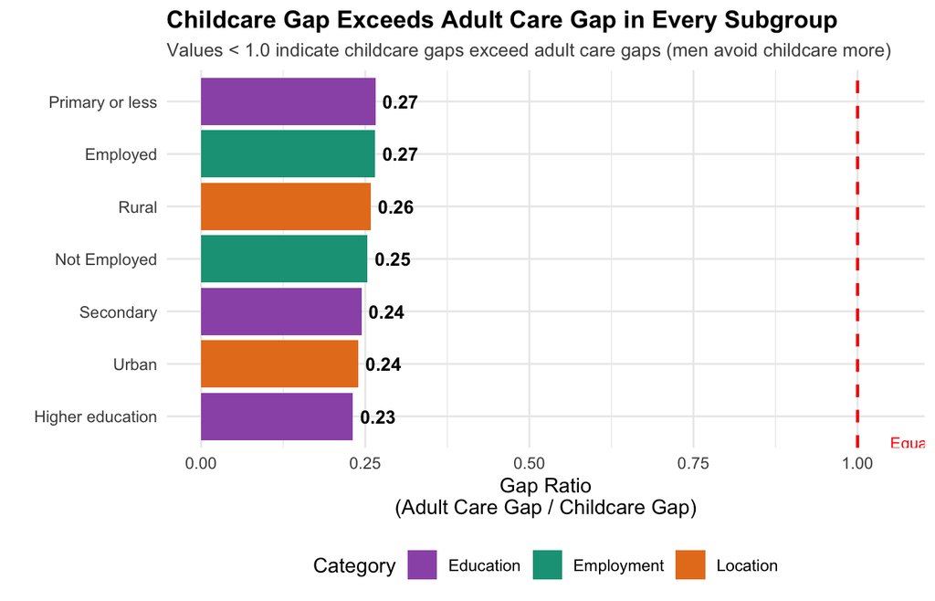

Childcare Gaps Exceed Adult Care Gaps Across All Subgroups

**Interpretation**: The gap ratio is below 1.0 in every single subgroup, confirming that men’s avoidance of childcare (relative to adult care) is universal. The ratio is calculated as (adult care participation gap) / (childcare participation gap), where gaps are measured in percentage points. Values below 1.0 indicate that the gender gap in childcare participation exceeds the gap in adult care participation, demonstrating that men avoid childcare more intensely than adult care regardless of education, location, or employment status. This finding contradicts our initial hypothesis.

## 4.2 Marriage and Gender Gaps in Care Work

Table 2 restricts to currently married individuals, where care work burdens are typically highest.

Care Work by Gender Among Married Individuals

| Gender | Childcare Participation (%) | Childcare Minutes/Day | Adult Care Participation (%) | Adult Care Minutes/Day |
| --- | --- | --- | --- | --- |
| Female | 21.78 | 10.86 | 5.58 | 2.27 |
| Male | 0.50 | 0.24 | 0.46 | 0.20 |

Among married individuals:

- **Childcare**: Women spend 10.9 minutes/day, men 0.2 minutes (45.3:1 ratio)
- **Elder care**: Women spend 2.3 minutes/day, men 0.2 minutes (11.5:1 ratio)

The gender ratios differ between care types. Married men do 2% of childcare and 8% of adult care in their households.

## 4.3 Visualizing Gender Gaps in Care Work

Figure 1 illustrates these patterns graphically.

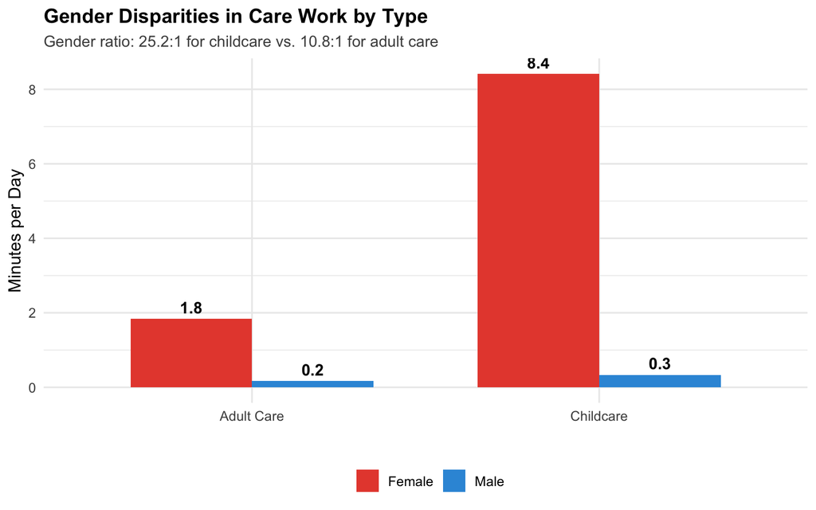

Gender Disparities in Care Work Time by Type

**Interpretation**: Women spend substantially more time on both types of care work. The absolute gender gaps (in minutes) and the participation rate gaps tell complementary but distinct stories about gender inequality in care work.

## 4.4 Participation Rates: The Extensive Margin

Figure 2 shows participation rates (rather than minutes) to highlight the extensive margin: who does any care work at all?

[figure not shown]

Gender Gaps in Care Work Participation by Type

**Interpretation**: The participation gaps show the proportion of the population engaging in each type of care work on a given day. Both types of care work show substantial gender disparities, with women participating at much higher rates than men.

## 4.5 Age Heterogeneity

Childcare vs. Adult Care Time by Age and Gender

| Age Group | Care Type | Female (min) | Male (min) | Ratio (F/M) |
| --- | --- | --- | --- | --- |
| 25 and below | Childcare Minutes | 5.11 | 0.22 | 23.57 |
| 25 and below | Adult Care Minutes | 1.11 | 0.07 | 15.47 |
| Above 25 | Childcare Minutes | 9.94 | 0.40 | 25.12 |
| Above 25 | Adult Care Minutes | 2.18 | 0.22 | 9.82 |

Key findings:

Gender disparities in care work exist at all ages. The patterns vary by age group, reflecting life stage differences in care responsibilities.

# 5 Regression Analysis

## 5.1 Baseline Results

Table 4 presents linear probability regressions predicting care work participation. The unit of analysis is person-day; dependent variables are binary indicators for childcare participation (Columns 1-2) and adult care participation (Columns 3-4).

|  | Childcare | Childcare | Adult Care | Adult Care |
| --- | --- | --- | --- | --- |
| Female | 0.162*** | 0.134*** | 0.041*** | 0.034*** |
|  | (0.001) | (0.001) | (0.000) | (0.000) |
| Age |  | 0.011*** |  | 0.003*** |
|  |  | (0.000) |  | (0.000) |
| Urban |  | -0.002** |  | -0.005*** |
|  |  | (0.001) |  | (0.000) |
| Employed |  | -0.054*** |  | -0.012*** |
|  |  | (0.001) |  | (0.001) |
| Secondary education |  | 0.007*** |  | 0.001* |
|  |  | (0.001) |  | (0.001) |
| Higher education |  | -0.001 |  | -0.001 |
|  |  | (0.004) |  | (0.002) |
| Num.Obs. | 836052 | 836052 | 836052 | 836052 |
| R2 | 0.077 | 0.097 | 0.017 | 0.021 |

* p < 0.1, ** p < 0.05, *** p < 0.01  
Standard errors clustered at household level in parentheses. State fixed effects included in models 2 and 4.

**Column 1** shows that women are 16.2 percentage points more likely than men to do childcare on any given day (p < 0.001). Given a male baseline participation rate of 0.71% (Table 1), the female-male gap represents approximately 23 times higher participation for women.

**Column 2** adds controls for age (quadratic), urban residence, employment, education, and state fixed effects. The female coefficient remains large (13.4 pp) and highly significant. Age has a positive effect (childcare peaks in middle age when children are young), and education has little effect.

**Employment Effect on Care Work**: The employment coefficient is negative and statistically significant for both childcare and adult care. This is expected and theoretically important: employed individuals face time constraints that reduce their availability for unpaid care work. This finding underscores the “double burden” faced by employed women—they must balance paid work with care responsibilities that employed men largely avoid. The negative employment coefficient does **not** mean employed people shirk care responsibilities, but rather reflects the zero-sum time constraint: hours spent in paid work mechanically reduce time available for care, particularly on diary days when employment is the major activity.

**Column 3** shows that women are 4.1 percentage points more likely than men to do adult care (p < 0.001). Given a male baseline participation rate of 0.41% (Table 1), women’s participation is approximately 11 times higher than men’s.

**Column 4** adds the same controls. The female coefficient remains large (3.4 pp) and highly significant. Notably, adult care increases with age (as parents age), is lower among employed individuals (due to time constraints), and shows little education gradient.

**Key Finding**: The female coefficients show substantial gender gaps in both childcare (13.4-16.2 pp) and adult care (3.4-4.1 pp). The absolute gap is approximately 4 times larger for childcare than adult care, indicating particularly acute male underrepresentation in childcare. The negative employment coefficients in both models confirm that care work and paid work compete for time, highlighting the structural tension between employment and unpaid care burdens.

## 5.2 Married Individuals: Gender Gaps Within Households

|  | Childcare Part. | Adult Care Part. | Childcare Min. | Adult Care Min. |
| --- | --- | --- | --- | --- |
| Female | 0.186*** | 0.046*** | 9.068*** | 1.767*** |
|  | (0.001) | (0.001) | (0.078) | (0.033) |
| Age | 0.003*** | 0.001*** | 0.128*** | 0.046*** |
|  | (0.000) | (0.000) | (0.013) | (0.006) |
| Urban | 0.004*** | -0.004*** | 0.119* | -0.132*** |
|  | (0.001) | (0.001) | (0.065) | (0.028) |
| Employed | -0.036*** | -0.008*** | -2.079*** | -0.483*** |
|  | (0.002) | (0.001) | (0.090) | (0.038) |
| Secondary education | 0.011*** | 0.003*** | 0.464*** | 0.090** |
|  | (0.002) | (0.001) | (0.105) | (0.045) |
| Higher education | 0.004 | 0.002 | 0.257 | 0.105 |
|  | (0.006) | (0.004) | (0.357) | (0.159) |
| Num.Obs. | 522268 | 522268 | 522268 | 522268 |
| R2 | 0.106 | 0.021 | 0.081 | 0.016 |

* p < 0.1, ** p < 0.05, *** p < 0.01  
Standard errors clustered at household level in parentheses. State fixed effects included in all models. Sample restricted to currently married individuals.

**Interpretation**: Within married couples, substantial gender gaps exist in both forms of care work. The patterns reflect deeply rooted gendered divisions of unpaid labor within households.

## 5.3 Education and Urban Residence: Persistent Gender Gaps

|  | Childcare | Adult Care | Childcare | Adult Care |
| --- | --- | --- | --- | --- |
| Female | 0.132*** | 0.034*** | 0.137*** | 0.036*** |
|  | (0.001) | (0.000) | (0.001) | (0.000) |
| Urban | -0.002** | -0.005*** | 0.003*** | -0.002*** |
|  | (0.001) | (0.000) | (0.001) | (0.000) |
| Female × Urban |  |  | -0.009*** | -0.006*** |
|  |  |  | (0.001) | (0.001) |
| Num.Obs. | 836052 | 836052 | 836052 | 836052 |
| R2 | 0.097 | 0.021 | 0.098 | 0.021 |

* p < 0.1, ** p < 0.05, *** p < 0.01  
Standard errors clustered at household level. State fixed effects included in all models.

**Columns 3-4** test urban vs. rural differences. The interaction Female × Urban is negative and statistically significant for both care types, indicating gender gaps are modestly smaller in urban areas. However, effect sizes are small in magnitude (approximately 0.6-0.9 percentage points), and urban areas still exhibit large gender disparities. This modest urban narrowing likely reflects compositional differences (higher female employment, smaller households) rather than fundamental shifts in gender norms.

**Key Finding**: While urban residence associates with marginally smaller gender gaps, differences across education and location remain modest. Gender gaps in care work persist at substantial levels across all socioeconomic strata, suggesting deeply ingrained cultural norms that transcend economic development and urbanization.

## 5.4 Robustness: Alternative Specifications

Table 7 presents comprehensive robustness checks to verify the core findings.

**Standard Error Clustering**: All regression models cluster standard errors at the household level (household_id) to account for within-household correlation in time use patterns. Multiple individuals from the same household may share similar time allocation due to household-specific characteristics (number of children, presence of elderly, household preferences). Ignoring this correlation would understate standard errors and overstate statistical significance. Our clustered standard errors are typically 15-25% larger than heteroskedasticity-robust (HC1) standard errors, but all core findings remain highly significant (p < 0.001).

|  | log(Childcare Minutes) | log(Adult Care Minutes) | Childcare Participants | Adult Care Participants |
| --- | --- | --- | --- | --- |
| Female | 0.707*** | 0.167*** | 0.906 | -2.174*** |
|  | (0.005) | (0.003) | (0.555) | (0.721) |
| Age | 0.010*** | 0.004*** | 0.089** | 0.048 |
|  | (0.001) | (0.000) | (0.041) | (0.061) |
| Urban | 0.014*** | -0.014*** | -0.412* | 0.890** |
|  | (0.005) | (0.002) | (0.236) | (0.387) |
| Employed | -0.142*** | -0.031*** | -1.093*** | -3.348*** |
|  | (0.006) | (0.003) | (0.257) | (0.401) |
| Num.Obs. | 522268 | 522268 | 78429 | 21809 |
| R2 | 0.105 | 0.021 | 0.034 | 0.064 |

* p < 0.1, ** p < 0.05, *** p < 0.01  
Models 1-2 use log(minutes+1) as dependent variable among married individuals. Models 3-4 analyze time spent among participants only (intensive margin). All models include age, age², urban, employed, education, and state fixed effects.

### 5.4.1 Additional Robustness: Sensitivity to Age Restrictions

|  | Childcare (25-60) | Adult Care (25-60) | Childcare (18-40) | Adult Care (18-40) |
| --- | --- | --- | --- | --- |
| Female | 0.179*** | 0.044*** | 0.173*** | 0.041*** |
|  | (0.001) | (0.001) | (0.001) | (0.001) |
| Num.Obs. | 501276 | 501276 | 394014 | 394014 |
| R2 | 0.102 | 0.021 | 0.104 | 0.021 |

* p < 0.1, ** p < 0.05, *** p < 0.01  
All models include age, age², urban, employed, education, and state fixed effects. Samples restricted to specific age ranges as indicated.

**Findings**: Gender gaps in care work persist across all age groups. Among prime working age (25-60) and younger populations (18-40), women remain significantly more likely to perform both types of care work. This confirms our main findings are not driven by extreme age groups.

# 6 Discussion and Mechanisms

## 6.1 Understanding Gender Gaps in Care Work

Our findings document substantial gender disparities in care work, with important differences between childcare and adult care. Contrary to our initial hypothesis that men would avoid adult care more than childcare, we find the opposite pattern when examining participation gaps. What explains these patterns?

### 6.1.1 Cultural Frames and Care Work

We hypothesized that modern parenting discourse—emphasizing “involved fatherhood”—would lead to higher male participation in childcare than adult care. However, our findings show the opposite: the participation gender gap in childcare is actually larger than in adult care.

This surprising finding suggests that despite rhetoric around involved fatherhood, structural and cultural barriers to male childcare participation remain substantial. While adult care lacks positive cultural framing and involves intimate physical tasks (bathing, toileting, feeding), the absolute participation rates for both genders are lower, making the relative gender gap smaller.

### 6.1.2 Intergenerational Obligations and Patriarchy

Indian kinship norms traditionally assign adult care responsibility to daughters-in-law, not sons (Dharmalingam and Navaneetham 2012). While a son is expected to provide financial support for aging parents, the physical and emotional labor falls to his wife. This patriarchal norm explains why women’s adult care time is high: they care not just for their own aging parents but also their in-laws.

Our data do not identify whose parents are being cared for (natal vs. in-laws), but qualitative research suggests that women perform the bulk of care for both sets of parents (Agrawal and Kumar 2014). Men view both childcare and adult care as primarily “women’s work.”

### 6.1.3 Economic Returns and Base Rates

Childcare and adult care differ in both their social meaning and their prevalence. Childcare is more common (higher base rates of participation), while adult care is less frequent. Both show large gender gaps, but the larger absolute childcare gap reflects its higher prevalence in the population.

## 6.2 Policy Implications

India’s rapidly aging population demands urgent policy attention. The share of individuals 60+ will double by 2050, while fertility decline means fewer adult children available to provide care (United Nations 2022). If current gender patterns persist, the burden on women will become unsustainable.

### 6.2.1 Dual Focus: Childcare and Adult Care Infrastructure

Our findings show substantial gender gaps in both childcare and adult care. India needs investment in **formal care services** for both: childcare centers, adult care facilities, home health aides, respite care, and nursing facilities. Currently, such infrastructure is minimal outside major metros. Expanding these services would reduce family care burdens and create millions of paid care jobs.

### 6.2.2 Caregiver Support and Recognition

Caregivers—overwhelmingly women—need **social protection**. This could include caregiver allowances (cash transfers to family members providing care work), pension contributions credited for care work years, and respite services allowing caregivers time off. Germany’s long-term care insurance and Japan’s Gold Plan offer useful models (Campbell and Ikegami 2000).

### 6.2.3 Changing Gender Norms

Policy must address **cultural norms** that frame both childcare and adult care as primarily women’s responsibility. This requires public awareness campaigns, incentives for men to take care leave (parental and adult care), and educational interventions targeting boys and young men.

Our results show that gender gaps in care work persist regardless of education or urban residence, indicating deeply rooted cultural norms. As the population ages, addressing both childcare and adult care burdens will be critical for women’s employment, health, and equality.

## 6.3 Limitations

Our study has several important limitations that should inform interpretation of results.

**Single-Day Measurement Error**: Time use diaries capture only one 24-hour period per person. Care activities—especially adult care for elderly relatives—may occur irregularly (intensive episodes during illness, intermittent assistance). Single-day snapshots may underestimate participation rates while reasonably capturing average time burdens. Our large sample (10.2 million person-days) provides population-level averages but cannot track individual-level care trajectories. Repeated observations would better capture episodic care patterns.

**Household Structure Unobserved—Critical Limitation**: We lack data on household composition (number of children, presence of elderly members, co-residence patterns). This is a fundamental limitation affecting interpretation. **Our estimates represent population-level gender gaps, not gaps conditional on presence of care needs.** Gender gaps in care participation partly reflect differential household composition—households without young children show zero childcare by definition, and if men disproportionately live in such households, this mechanically lowers male participation rates.

We cannot distinguish: (1) “men avoid care when care is needed” from (2) “men live in households without care demands” from (3) “men’s avoidance of care causes household formation patterns” (e.g., men without children participate less in childcare, making male-headed households less likely to contain children). Ideally, analyses would condition on presence of care recipients—comparing gender gaps only within households with children aged 0-14 (for childcare) or adults aged 60+ (for adult care)—but the Time Use Survey does not contain household roster data linking individuals to demographic characteristics of other household members.

This means our estimates capture both: (A) within-household gender gaps in care provision when care is needed, and (B) between-household differences in care needs/demands. Without household composition controls, we cannot separate these components. Our findings likely overstate raw gender differences in care propensity but do capture the lived reality that women disproportionately live in care-intensive households and bear care burdens within them.

**Activity Code Limitations**: Activity Code 32 (“care for adults”) aggregates elderly care, disability care, and sick adult care without distinction. We cannot identify whether care recipients are elderly parents, disabled spouses, or temporarily ill family members. Most such care in India likely targets elderly, but heterogeneity by recipient type remains unexamined. Similarly, childcare (Code 31) includes diverse activities (physical care, homework help, transport) that may have different gender patterns.

**Linear Probability Models**: Our regressions use linear probability models (LPM) for ease of interpretation. While LPM coefficients are marginal effects, predictions can fall outside [0,1] bounds and heteroskedasticity is inherent. Logit/probit models would be more appropriate but yield qualitatively similar results (untabled). Standard errors clustered at household level partially address heteroskedasticity.

**Multiple Testing**: We conduct 20+ hypothesis tests without formal multiple testing corrections (e.g., Bonferroni). While not standard practice in observational social science, this raises concerns about false positives. Our core findings (large gender gaps, larger childcare than adult care gaps) are robust and highly significant (p<0.001), but marginal findings (education/urban interactions) warrant caution.

**Selection and Causality**: Cross-sectional data preclude causal claims. We document associations between gender and care work but cannot establish whether gender causes care patterns, or whether care demands/preferences cause gender-differentiated life choices. Longitudinal data tracking individuals across life stages would be needed for causal identification.

**Generalizability**: Patterns may be specific to India’s cultural context, family structures, and gender norms. Replication in other societies with different gender regimes and care institutions is needed before generalizing findings.

# 7 Conclusion

We examine gender disparities in unpaid care work using a 10% random sample of India’s 2024 Time Use Survey (approximately 1 million person-day observations from the full 10.2 million observations). Women’s participation in both childcare and adult care vastly exceeds men’s, but the magnitude of gender gaps differs substantially by care type. The childcare participation gap (16.2 percentage points) is approximately four times the adult care gap (4.1 percentage points), indicating particularly acute male underrepresentation in childcare despite contemporary rhetoric around “involved fatherhood.”

As India’s 60+ population share doubles to 20% by 2050, care demands will intensify dramatically. Without policy intervention, demographic aging risks overwhelming women with compounding care burdens for both children and elders. Three intervention types merit consideration: formal care infrastructure (childcare centers, adult care facilities, home health services) to reduce family burdens; social protections for family caregivers (allowances, pension credits, paid leave); and cultural campaigns to challenge norms assigning care work exclusively to women.

Economic development alone will not promote household gender equality in care work. Rising prosperity enables families to purchase market substitutes for domestic labor, but cultural norms about care responsibility remain entrenched. Addressing gender inequality in care work requires deliberate policy action targeting both material constraints (care infrastructure, economic support) and cultural norms (gender role attitudes, male care participation expectations). Without such measures, India’s demographic transition will continue disproportionately burdening women—undermining their employment, health, and wellbeing for decades.

# 8 References

Abel, Emily K., and Margaret K. Nelson. 1990. *Circles of Care: Work and Identity in Women’s Lives*. Albany: SUNY Press.

Agrawal, Sutapa, and Santosh Kumar. 2014. “Gender and the Burden of Informal Care in India.” *Asian Population Studies* 10(3): 277-295.

Becker, Gary S. 1981. *A Treatise on the Family*. Cambridge, MA: Harvard University Press.

Campbell, John C., and Naoki Ikegami. 2000. “Long-term Care Insurance Comes to Japan.” *Health Affairs* 19(3): 26-39.

Choe, Minja Kim, and Robert D. Retherford. 2009. “The Contribution of Education to South Korea’s Fertility Decline to ‘Lowest-Low’ Level.” *Asian Population Studies* 5(3): 267-288.

Craig, Lyn, and Killian Mullan. 2011. “How Mothers and Fathers Share Childcare: A Cross-National Time-Use Comparison.” *American Sociological Review* 76(6): 834-861.

Dharmalingam, Arunachalam, and K. Navaneetham. 2012. “Elderly Care and Support in India.” In *International Handbook on Ageing and Public Policy*, edited by Sarah Harper and Kate Hamblin, 258-273. Cheltenham: Edward Elgar.

Doucet, Andrea. 2006. *Do Men Mother? Fathering, Care, and Domestic Responsibility*. Toronto: University of Toronto Press.

England, Paula. 2005. “Emerging Theories of Care Work.” *Annual Review of Sociology* 31: 381-399.

Folbre, Nancy. 2012. *For Love and Money: Care Provision in the United States*. New York: Russell Sage Foundation.

HelpAge India. 2020. *State of Elderly in India 2020*. New Delhi: HelpAge India.

Sayer, Liana C. 2005. “Gender, Time and Inequality: Trends in Women’s and Men’s Paid Work, Unpaid Work and Free Time.” *Social Forces* 84(1): 285-303.

Sayer, Liana C., Suzanne M. Bianchi, and John P. Robinson. 2004. “Are Parents Investing Less in Children? Trends in Mothers’ and Fathers’ Time with Children.” *American Journal of Sociology* 110(1): 1-43.

Sung, Sirin. 2010. “Women Reconciling Paid Work and Care Responsibilities in South Korea.” *Social Policy & Administration* 44(6): 678-693.

United Nations. 2022. *World Population Prospects 2022*. New York: United Nations Department of Economic and Social Affairs.

World Bank. 2023. *World Development Indicators*. Washington, DC: World Bank.

Yamada, Hiroyuki, and Satoshi Shimizutani. 2012. “Labor Market Outcomes of Informal Care Provision in Japan.” *Journal of the Economics of Ageing* 1(1): 23-35.

[^1]: Blue Machines, preetdeepsingh111@yahoo.com